# Project: COVID Tweet Sentiment Analysis

#### Made By:

#### Ashwani Tanwar (2019UCS2034)

#### Ritesh Kumar (2019UCS2035)

#### Yash Sethia (2019UCS2036)

#### Shubham (2019UCS2058)

The complete implementation of this project is provided in the zip file attached.

```python
!pip install wordcloud
```

```
     -------------------------------------- 220.7/220.7 KB 2.2 MB/s eta 0:00:00
  Preparing metadata (setup.py): started
  Preparing metadata (setup.py): finished with status 'done'
```

[output not shown]

## Libraries to be used in this program

The model uses a deep neural network based model to classify the tweets. We have used a LSTM model with word embedding layers provided by tensorflow. The following libraries have been used in the implementation of this model:

1. Numpy
2. Pandas
3. Matplotlib
4. Seaborn
5. NLTK
6. Word Cloud
7. Sklearn
8. Tensorflow
9. Keras

```python
import numpy as np
import pandas as pd

import seaborn as sns
import matplotlib.pyplot as plt
%matplotlib inline

import re
import string
from collections import defaultdict, Counter
from nltk.corpus import stopwords
from nltk.stem import WordNetLemmatizer
from wordcloud import WordCloud, STOPWORDS, ImageColorGenerator

from sklearn.model_selection import StratifiedShuffleSplit
from sklearn.metrics import accuracy_score, classification_report, f1_score
from sklearn.metrics import confusion_matrix

from tensorflow.keras.preprocessing.text import Tokenizer
from tensorflow.keras.preprocessing.sequence import pad_sequences

import tensorflow as tf
from keras.models import Sequential
import tensorflow.keras.layers as L
from tensorflow.keras.optimizers import Adam
from keras.callbacks import EarlyStopping,ReduceLROnPlateau

from wordcloud import WordCloud
from sklearn.feature_extraction.text import CountVectorizer


from tensorflow.keras.preprocessing.text import Tokenizer
from tensorflow.keras.preprocessing.sequence import pad_sequences
from tensorflow.keras.models import Sequential
from tensorflow.keras.layers import Dense, Embedding, LSTM, SpatialDropout1D
from sklearn.model_selection import train_test_split
```

## Dataset

The model is trained using the kaggle dataset of tweets regarding COVID-19. It is in the form of 2 CSV files i.e. Corona_NLP_train.csv and Corona_NLP_test.csv.

The tweets have been pulled from Twitter and manual tagging has been done later. The names and usernames have been given codes to avoid any privacy concerns.

The columns present in the dataset are:

1. Location
2. Tweet At
3. Original Tweet
4. Label

```python
train_df = pd.read_csv("./Corona_NLP_train.csv", encoding='latin-1')
test_df=pd.read_csv("./Corona_NLP_test.csv")
```

```python
def vis_conf_matrix(conf_martix, model_name):
    group_names = ['True Neg', 'False Pos', 'False Neg', 'True Pos']
    group_counts = ["{0:0.0f}".format(value) for value in
                    conf_martix.flatten()]
    group_percentages = ["{0:.2%}".format(value) for value in
                         conf_martix.flatten()/np.sum(conf_martix)]
    labels = [f"{v1}\n{v2}\n{v3}" for v1, v2, v3 in
              zip(group_names,group_counts,group_percentages)]
    labels = np.asarray(labels).reshape(2,2)

    _, ax = plt.subplots(figsize = (6,6))
    ax = sns.heatmap(conf_martix, annot=labels, fmt = '',
                     annot_kws = {"size": 20, "weight": "bold"}, cmap = 'Blues')
    labels = ['False', 'True']
    ax.set_title('Confusion Matrix for {}'.format(model_name), fontsize = 15)
    ax.set_xticklabels(labels, fontsize = 10)
    ax.set_yticklabels(labels, fontsize = 10)
    ax.set_xlabel('Prediction', fontsize = 15)
    ax.set_ylabel('Ground Truth', fontsize = 15)
```

## Analysing Data

The data had sentiments like **Positive**, **Negative**, **Neutral**, **Extremely Positive** and **Extremely Negative**.

After that we removed the URLs, HTML tags, numeric digits and punctuation marks from the tweets in order to focus better on the words, we converted all letters into lower case for uniformity.

```python
train_df['label'] = train_df['Sentiment'].factorize()[0]
train_df['label'].nunique()
```

```
5
```

```python
train_df.head()
```

|  | UserName | ScreenName | Location | TweetAt | OriginalTweet | Sentiment | label |
| --- | --- | --- | --- | --- | --- | --- | --- |
| 0 | 3799 | 48751 | London | 16-03-2020 | @MeNyrbie @Phil_Gahan @Chrisitv https://t.co/i... | Neutral | 0 |
| 1 | 3800 | 48752 | UK | 16-03-2020 | advice Talk to your neighbours family to excha... | Positive | 1 |
| 2 | 3801 | 48753 | Vagabonds | 16-03-2020 | Coronavirus Australia: Woolworths to give elde... | Positive | 1 |
| 3 | 3802 | 48754 | NaN | 16-03-2020 | My food stock is not the only one which is emp... | Positive | 1 |
| 4 | 3803 | 48755 | NaN | 16-03-2020 | Me, ready to go at supermarket during the #COV... | Extremely Negative | 2 |

[output not shown]

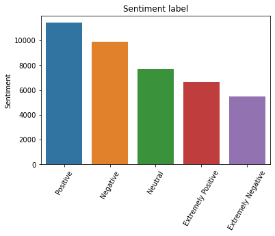

```python
sns.barplot(x = train_df['Sentiment'].value_counts().index,
            y = train_df['Sentiment'].value_counts()).set_title('Sentiment label')
plt.xticks(rotation = 60)
```

```python
train_df['Sentiment']
train_df.groupby(['Sentiment','label']).size().reset_index()
```

|  | Sentiment | label | 0 |
| --- | --- | --- | --- |
| 0 | Extremely Negative | 2 | 5481 |
| 1 | Extremely Positive | 4 | 6624 |
| 2 | Negative | 3 | 9917 |
| 3 | Neutral | 0 | 7713 |
| 4 | Positive | 1 | 11422 |

```python
sentiment = {0: "Neutral", 1: "Positive", 2: "Extremely Negative", 3: "Negative", 4: "Extremely Positive"}
```

```python
# Remove Urls and HTML links
def remove_urls(text):
    url_remove = re.compile(r'https?://\S+|www\.\S+')
    return url_remove.sub(r'', text)

def remove_html(text):
    html = re.compile(r'<.*?>')
    return html.sub(r'', text)

# Lower casing
def lower(text):
    low_text = text.lower()
    return low_text

# Number removal
def remove_num(text):
    remove = re.sub(r'\d+', '' ,text)
    return remove
def punctuation_removal(messy_str):
    clean_list = [char for char in messy_str if char not in string.punctuation]
    clean_str = ''.join(clean_list)
    return clean_str


train_df['OriginalTweet'] = train_df['OriginalTweet'].apply(lambda x: remove_urls(x))
train_df['OriginalTweet'] = train_df['OriginalTweet'].apply(lambda x: remove_html(x))
train_df['OriginalTweet'] = train_df['OriginalTweet'].apply(lambda x: lower(x))
train_df['OriginalTweet'] = train_df['OriginalTweet'].apply(lambda x: remove_num(x))
train_df['OriginalTweet'] = train_df['OriginalTweet'].apply(lambda x: punctuation_removal(x))
#data.drop(columns = ['OriginalTweet'], inplace = True)
```

[output not shown]

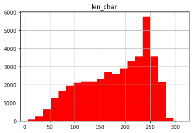

```python
train_df['len_char'] = train_df.OriginalTweet.apply(lambda x: len(x))
train_df.hist(column = 'len_char', bins = 20,color='red')
```

```python
def create_corpus(train_df, target_label, label_col = 'label', text_col = 'OriginalTweet'):
    corpus = []

    for x in train_df[train_df[label_col] == target_label][text_col].str.split():
        for i in x:
            corpus.append(i)
    return corpus
```

```python
corpus_pos = create_corpus(train_df, 1)
corpus_neg = create_corpus(train_df, 0)

print("Positives: ", len(corpus_pos))
print("Negatives: ", len(corpus_neg))
```

```
Positives:  338521
Negatives:  167395
```

## Data Visualization

After the data preprocessing, we used the frequency of the words in our corpus to create a Word Cloud for our dataset. The output was like this:

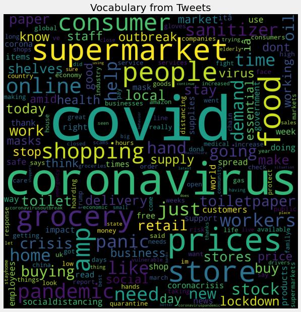

```python
# lets plot the Wordscloud
cv = CountVectorizer(stop_words = 'english')
words = cv.fit_transform(train_df['OriginalTweet'])
sum_words = words.sum(axis=0)

words_freq = [(word, sum_words[0, idx]) for word, idx in cv.vocabulary_.items()]
words_freq = sorted(words_freq, key = lambda x: x[1], reverse = True)

wordcloud = WordCloud(background_color = 'black', width = 2000, height = 2000).generate_from_frequencies(dict(words_freq))

plt.style.use('fivethirtyeight')
plt.figure(figsize=(10, 10))
plt.axis('off')
plt.imshow(wordcloud)
plt.title("Vocabulary from Tweets", fontsize = 20)
plt.show()
```

### Preparing data for NLP model

For our NLP model, we only need the **Orignal Tweet** and the **Label** from the data. Hence we extract the 2 columns from the above dataframe.

Then the data is tokenized and the top 2000 most frequently used words are chosen. The tokens are padded the the same length of 28 and the label is converted into dummy variables.

Now we can split the data into 80% training data and 20% test data and prepare our model.

```python
# Keeping only the neccessary columns
data = train_df[['OriginalTweet','label']]
```

```python
data['OriginalTweet'].values
```

```
array(['menyrbie philgahan chrisitv  and  and ',
       'advice talk to your neighbours family to exchange phone numbers create contact list with phone numbers of neighbours schools employer chemist gp set up online shopping accounts if poss adequate supplies of regular meds but not over order',
       'coronavirus australia woolworths to give elderly disabled dedicated shopping hours amid covid outbreak ',
       ...,
       'you know itâ\x92s getting tough when kameronwilds  is rationing toilet paper coronavirus toiletpaper kroger martinsville help us out',
       'is it wrong that the smell of hand sanitizer is starting to turn me on\r\r\n\r\r\ncoronavirus covid coronavirus',
       'tartiicat well newused rift s are going for  on amazon rn although the normal market price is usually   prices are really crazy right now for vr headsets since hl alex was announced and its only been worse with covid up to you whethe'],
      dtype=object)
```

```python
max_fatures = 2000

tokenizer = Tokenizer(num_words=max_fatures, split=' ')

# Updating internal vocablury of the tokenizer
tokenizer.fit_on_texts(data['OriginalTweet'].values)
X = tokenizer.texts_to_sequences(data['OriginalTweet'].values)

#Padding the tokens to the same length
X = pad_sequences(X, 28)

# Coverting labels to dummy variables
Y = pd.get_dummies(data['label']).values
```

```python
# Spliting the data to 80% training data and 20% test data
X_train, X_test, Y_train, Y_test = train_test_split(X,Y, test_size = 0.20)

print("The shape of training features:",X_train.shape)
print("The shape of testing features:",X_test.shape)
print("The shape of training labels:",Y_train.shape)
print("The shape of testing labels:",Y_test.shape)
```

```
The shape of training features: (32925, 28)
The shape of testing features: (8232, 28)
The shape of training labels: (32925, 5)
The shape of testing labels: (8232, 5)
```

## Model

Our Neural Net model for the problem looks like this:

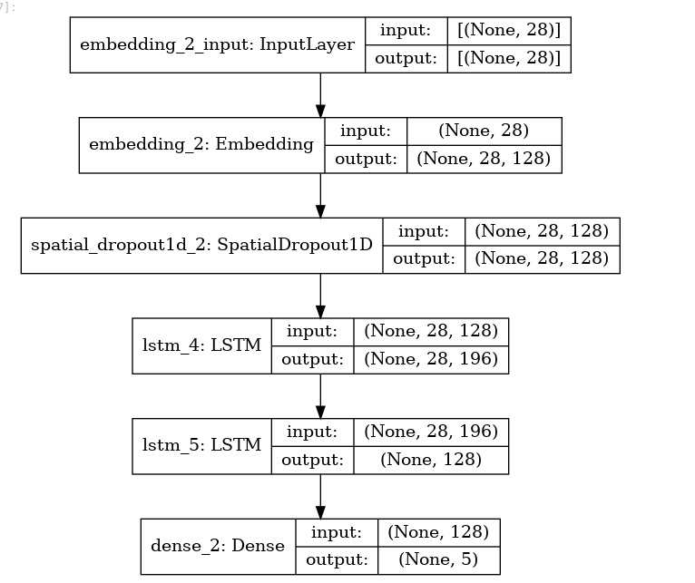

The word embedding layers are responsible for converting the string tokens into numbers so that they can be used for learning in the neural network model. The dropout layer ensures that the best architecture of no. of units in each hidden layer is used for the model. LSTM layers are used because the tweets have a context related which needs to be captured using the memory component of LSTM layers. Finally using the dense layer to provide a feed forward neural network learning.

We have used Binary Cross-entropy as loss function, Adam as the optimizer and accuracy as the performance metric. Finally we used a batch size of 512 to fit the data on our model with 100 epochs. The model is finally saved for future use.

```python
embed_dim = 128
lstm_out = 196

model = Sequential()
# Special Layer for NLP applications that perform One0Hot encoding for the tokens along with dimensionality reduction
model.add(Embedding(max_fatures, embed_dim, input_length = X.shape[1]))
model.add(SpatialDropout1D(0.4))
model.add(LSTM(lstm_out, dropout=0.3, recurrent_dropout=0.2, return_sequences=True))
model.add(LSTM(128,recurrent_dropout=0.2))
model.add(Dense(5,activation='softmax'))

history=model.compile(loss = 'BinaryCrossentropy', optimizer='adam',metrics = ['accuracy'])
```

### Running the model

The summary of the model is shown below. The model in total has **677,845 parameters**. We run the model for **100 epochs** with a **batch size of 512**.

```python
model.summary()
```

```
Model: "sequential"
_________________________________________________________________
 Layer (type)                Output Shape              Param #
=================================================================
 embedding (Embedding)       (None, 28, 128)           256000

 spatial_dropout1d (SpatialD  (None, 28, 128)          0
 ropout1D)

 lstm (LSTM)                 (None, 28, 196)           254800

 lstm_1 (LSTM)               (None, 128)               166400

 dense (Dense)               (None, 5)                 645

=================================================================
Total params: 677,845
Trainable params: 677,845
Non-trainable params: 0
_________________________________________________________________
```

```python
batch_size = 512

model.fit(X_train, Y_train, epochs = 100, batch_size=batch_size, validation_data=(X_test, Y_test))
```

```
<keras.callbacks.History at 0x1d693cd6d60>
```

```python
m1=model.save('h2')
print(m1)

loss,accuracy=model.evaluate(X_train,Y_train)
```

```
INFO:tensorflow:Assets written to: h2\assets
```

[output not shown]

```
None
```

## Performance Analysis

```python
print(loss)
print(accuracy)
```

```
0.03945654630661011
0.9736977815628052
```

```python
from keras.models import load_model
model = load_model('h2')
```

```python
loss,accuracy = model.evaluate(X_train,Y_train)
print(loss)
print(accuracy)
```

[output not shown]

## Testing against user inputs

```python
#user = ['With 100  nations inficted with  covid  19  the world must  not  play fair with china  100 goverments must demand  china  adopts new guilde  lines on food safty  the  chinese  goverment  is guilty of  being  irosponcible   with life  on a global scale']
#user = ['COVID-19 restrictions sparking a run on grocery stores. They are not closed yet! But Customers are stocking up on groceries this weekend, preparing for what could be more retail store restrictions in coming days.']
user = ['Coronavirus fun fact: if you cough at the grocery store, you get the whole aisle to yourself pretty quickly. #CoronavirusOutbreak #coronavirus #COVID2019']


user = list(map(lambda x: remove_urls(x), user))
user = list(map(lambda x: remove_html(x), user))
user = list(map(lambda x: lower(x), user))
user = list(map(lambda x: remove_num(x), user))
user = list(map(lambda x: punctuation_removal(x), user))

X_user = tokenizer.texts_to_sequences(user)
X_user = pad_sequences(X_user, 28)
result = model.predict(X_user)
sentiment[np.argmax(result)]
```

```
'Extremely Positive'
```

## Testing for tweets in Test Data

```python
index = 73
X_user = X_test[index].reshape(1,-1)
result = model.predict(X_user)
print("The predicted label is: {}".format(sentiment[np.argmax(result)]))
print("The actual label is: {}".format(sentiment[np.argmax(Y_test[index])]))
```

```
The predicted label is: Extremely Negative
The actual label is: Extremely Negative
```